# Statistical methods for multi-location studies in environmental epidemiology

Pierre Masselot

# Introduction: Multi-location studies for environmental epidemiology

## Environment and health

Environmental exposure are important health risk factors

Collectively responsible for millions of deaths each year

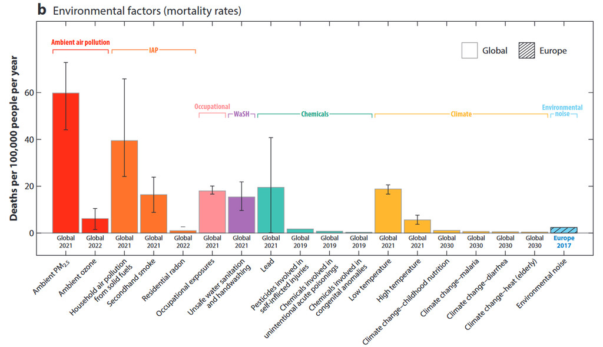

Clark et al. (2025)

## Effects difficult to estimate

The impacts of ambient environmental exposures can be difficult to estimate

- Small effects: increase risks of adverse outcomes slightly
- Large impacts: everybody is exposed
- Exposition differs between populations

⇒ We typically use several locations to alleviate these issues

## Air pollution and health

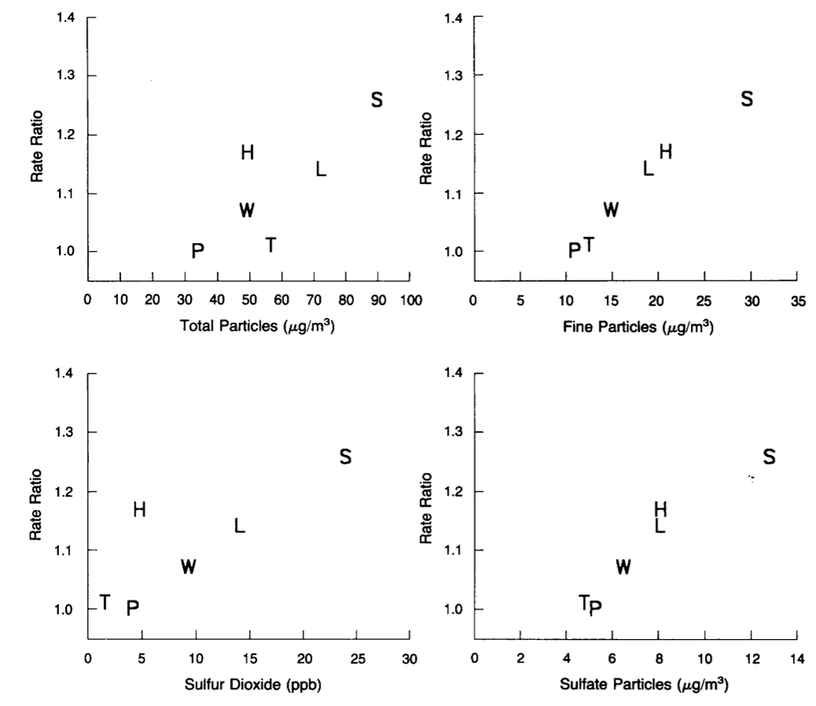

Harvard’s six cities study gathered a large cohort (Dockery et al., 1993)

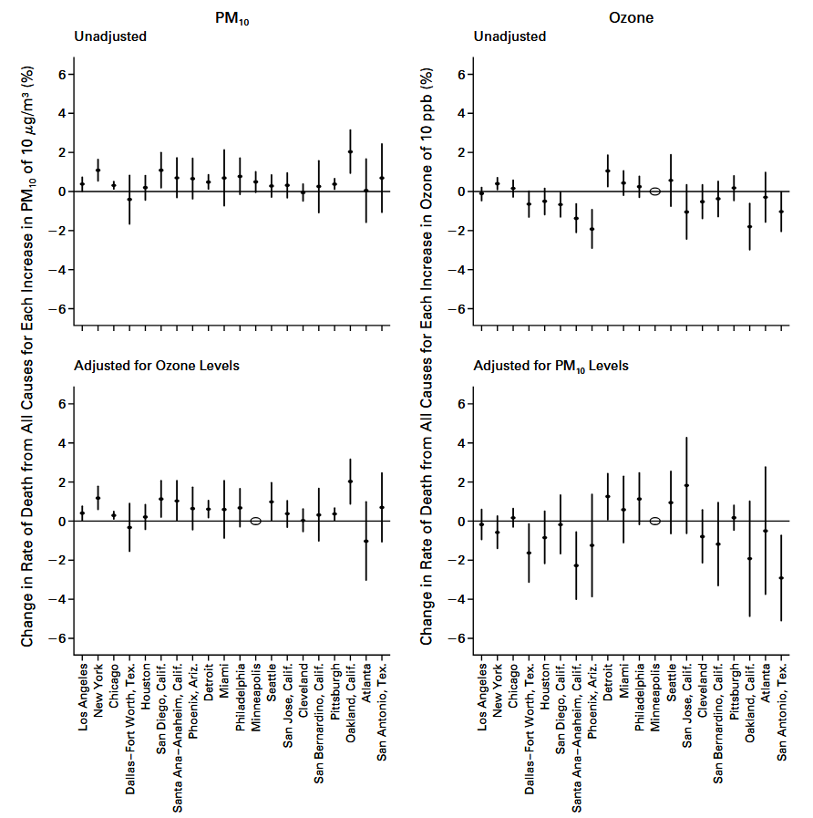

Time series of pollutants and mortality in 20 cities (Samet et al., 2000)

## Non-optimal temperature and health

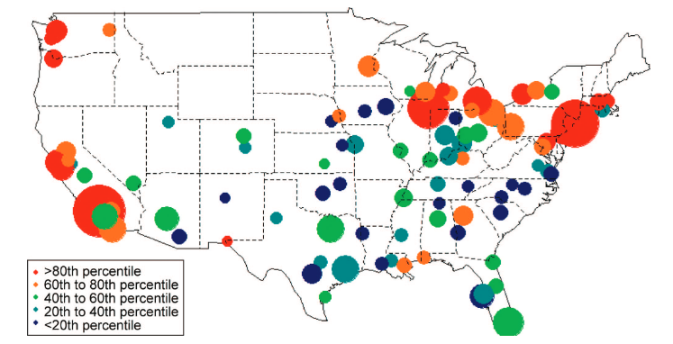

Heat and cold across the US (Anderson and Bell, 2009)

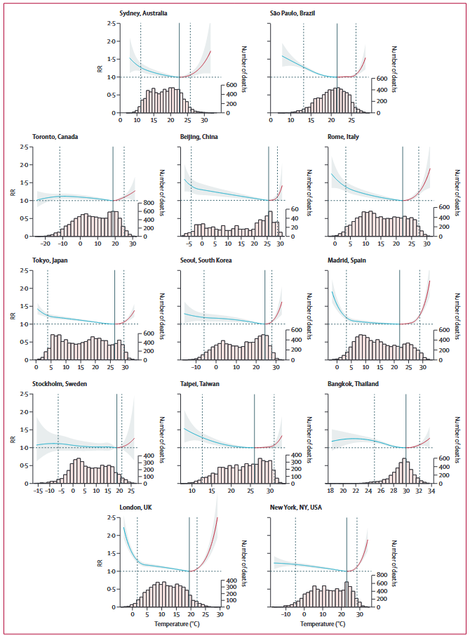

An international study with hundreds of cities (Gasparrini et al., 2015)

## Why multi-location studies?

More power to detect and estimate associations

- Allows bigger populations by considering several locations

Higher contrasts of exposure

- Different location will typically have very different levels

Estimation of heterogeneity of effects

- Allows to understand how the risk vary

## The two-stage framework

1. Estimation of the association in each location independently
2. Pool estimated association in a meta-analysis model

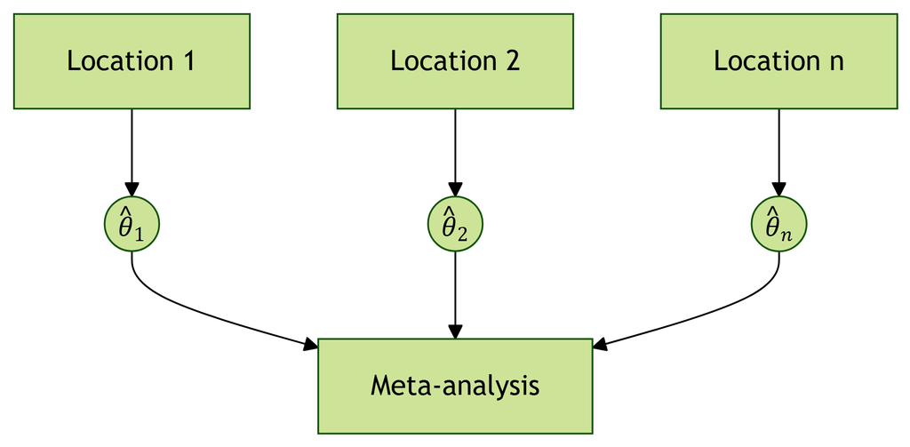

## Main features

Advantages

- **Computational gain**: management of nuisance parameters
- **Data protection**: large-scale studies with no data centralisation

Features

- Improved estimates (BLUPs)
- Uncertainty management
- Estimating effect modification

## Plan

We’ll go through the main models for each stage

**Stage 1**: Distributed-lag (nonlinear) models

**Stage 2**: Mixed-effect meta-analysis

## Material

The whole material is available on GitHub

[figure not shown]

# First stage: distributed-lag (nonlinear) models

## Example data

Association between coarse particulate matter and mortality

$$\text{Deaths} \sim f(\text{PM}_{10})$$

- Deaths: daily counts
- PM<sub>10</sub>: Coarse particulate matter concentration ($\mu g/m^3$)

Study area: London

Period: 1996-2001

## A look at the data

| date | death | tmean |
| --- | --- | --- |
| 1996-01-01 | 260 | 3.8 |
| 1996-01-02 | 278 | 4.8 |
| 1996-01-03 | 266 | 5.0 |
| 1996-01-04 | 248 | 5.4 |
| 1996-01-05 | 279 | 6.6 |
| 1996-01-06 | 262 | 8.2 |

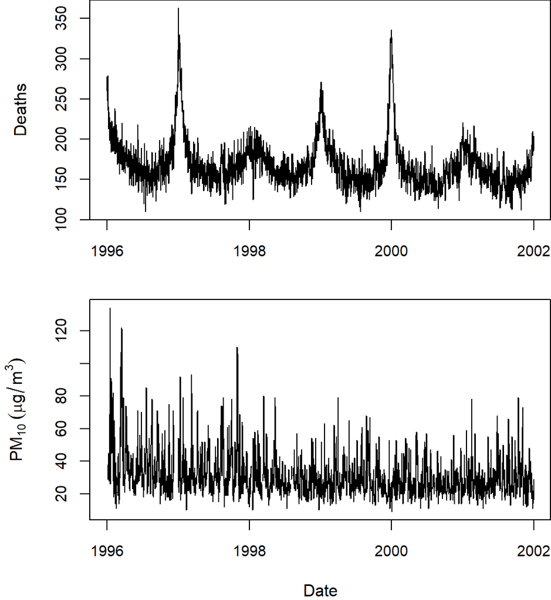

## The time-series design

These data are a typical example of a **time series design**

Important design in environmental epidemiology

- Allows estimating lags
- Use ecological data

**Note**

The methods we will see can be used with other designs:

Case-crossover, Case time series, Cohorts

## Poisson model

Response $y_t$ is a count: we use a Poisson model<sup>1</sup>

$$\mathbb{E}(y_t) = \exp \left(\alpha + \color{red}{x_t \beta} + \sum_{j=1}^p z_{tj} \gamma_j\right)$$

- $\color{red}{x_t}$: Exposure (PM<sub>10</sub>)
- $z_{tj}$: Covariates (Confounders such as day-of-year, day-of-week, etc)
[^1]: We often use a quasi-Poisson likelihood due to over-dispersion

## The typical time series model

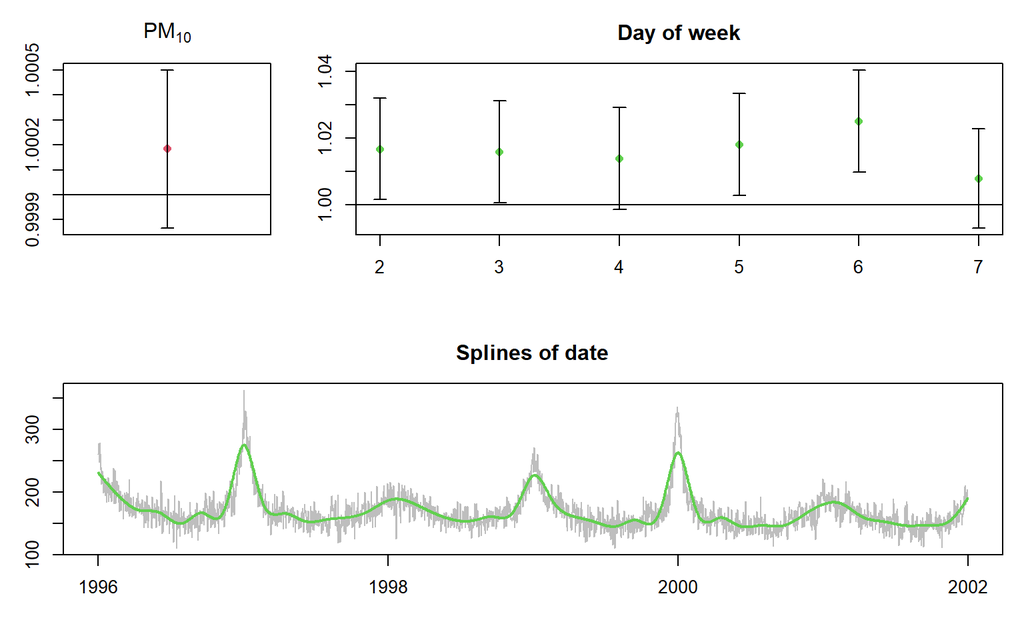

RR: Relative risk $e^{\beta}$, RR = 1 means no association

## Lagged association

The model becomes

$$\mathbb{E}(y_t) = \exp \left(\alpha + \color{red}{\sum_{l=0}^L \beta_l x_{t-l}} + \sum_{j=1}^p z_{tj} \gamma_j\right)$$

| Date | Deaths | PM10 (t-0) | PM10 (t-1) | PM10 (t-2) |
| --- | --- | --- | --- | --- |
| 1996-01-21 | 207 | 69 | 57 | 70 |
| 1996-01-22 | 184 | 91 | 69 | 57 |
| 1996-01-23 | 198 | 74 | 91 | 69 |

## Lagged PM<sub>10</sub> association

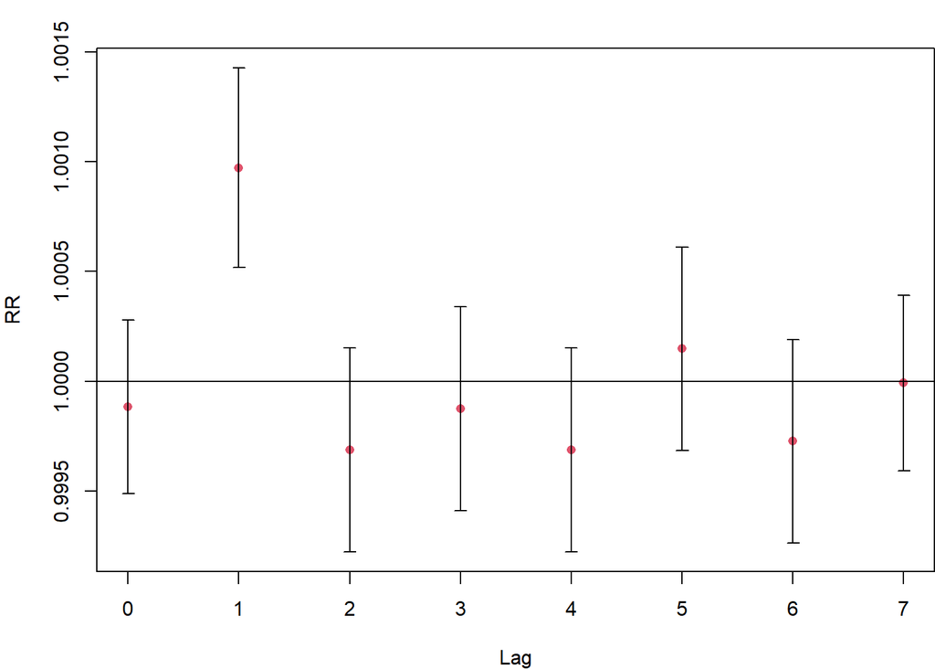

## Issues with lagged association

High degree of autocorrelation in environmental exposures

- Collinearity between the $\color{red}{x_{t-l}}$
- Unstable estimates (increased variance)

Not suitable for long lag periods

- High dimensional predictors
- Decreases power

## Distributed-lag models (DLM)

Represents a lagged association as a **smooth function of lags**

$$\beta_l = f(l)$$

$$\mathbb{E}(y_t) = \exp \left(\alpha + \color{red}{\sum_{l=0}^L f(l) x_{t-l}} + \sum_{j=1}^p z_{tj} \gamma_j \right)$$

This provides a **lag-response function**

- Representing how association varies with lag

## Basis representation

Smooth function $f(l)$ can be estimated by **basis representation**:

$$\beta_l = f(l) = \sum_k \theta_k b_k(l)$$

- $b_k(l)$ are predefined **basis functions**
- $\theta_k$ associated parameters

⇒ Flexible representation of nonlinear functions as a *linear combination*

## Examples of bases $b_k(l)$

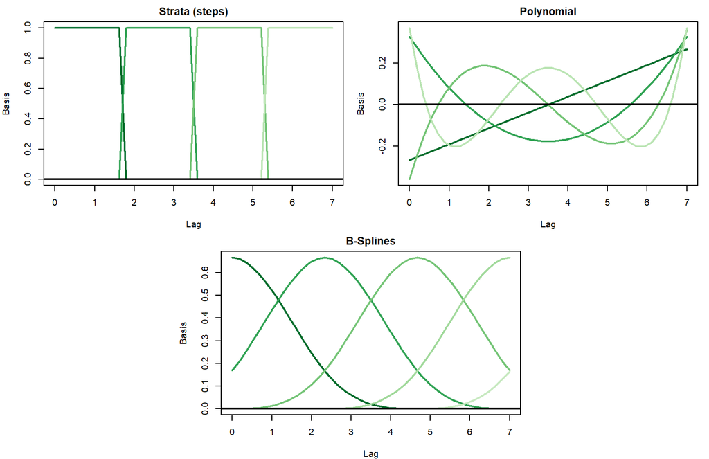

## Fitting DLMs

With basis expansion we have

$$\begin{align}
\color{red}{\sum_{l} x_{t-l} \beta_l} &= \sum_{l} x_{t-l} \sum_k \theta_k b_k(l) \\
&= \sum_k \theta_k \sum_l x_{t-l} b_k(l)
\end{align}$$
We define $k$ new variables $\color{red}{v_k = \sum_l x_{t-l} b_k(l)}$ to obtain the Poisson model

$$\mathbb{E}(y_t) = \exp \left(\alpha + \color{red}{\sum_{l=0}^L \theta_k v_k} + \sum_{j=1}^p z_{tj} \gamma_j\right)$$

## Fitting DLMs: matrix form

In matrix form, the basis expansion becomes

$$\begin{align}
\color{red}{\mathbf{x}_t^T \boldsymbol{\beta}} &= \mathbf{x}_t^T \begin{bmatrix} \mathbf{b}^T(1)\boldsymbol{\theta} \\ \vdots \\ \mathbf{b}^T(L)\boldsymbol{\theta} \end{bmatrix} \\
&= \mathbf{x}_t^T \mathbf{B} \boldsymbol{\theta}
\end{align}$$

The new predictor vector is then $\mathbf{v}_t^T = \mathbf{x}_t^T \mathbf{B}$

Vector $\mathbf{b}(l)$ contains the $K$ basis functions evaluated at lag $l$

Matrix $\mathbf{B}$ contains the basis $b_k(l)$ at row $l$ and column $k$

## Lag-response function of PM<sub>10</sub>

- Natural cubic splines
- Knots placed at lags 1 and 3

⇒ Four basis functions

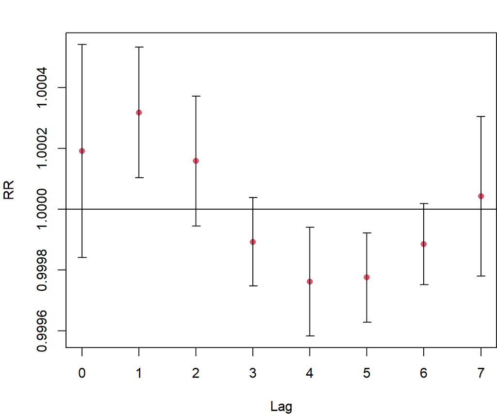

## Nonlinear associations: temperature

DLMs still assume a **linear** association at each lag

This is typically not realistic for temperature

- Increased risk for both heat and cold

Therefore we seek to relax this assumption with a model of the form

$$\color{red}{\sum_{l} f(x_{t-l}, l)}$$

- Smooth over both $x_{t-l}$ and $l$

## Tensor product

Estimate the two-dimensional surface

$$f(x,l) = \sum_m^M \sum_k^K \theta_{mk} a_m(x) b_k(l)$$

- $a_m(x)$ and $b_k(l)$ are two sets of basis functions
- They can be different- (e.g. polynomials and splines)

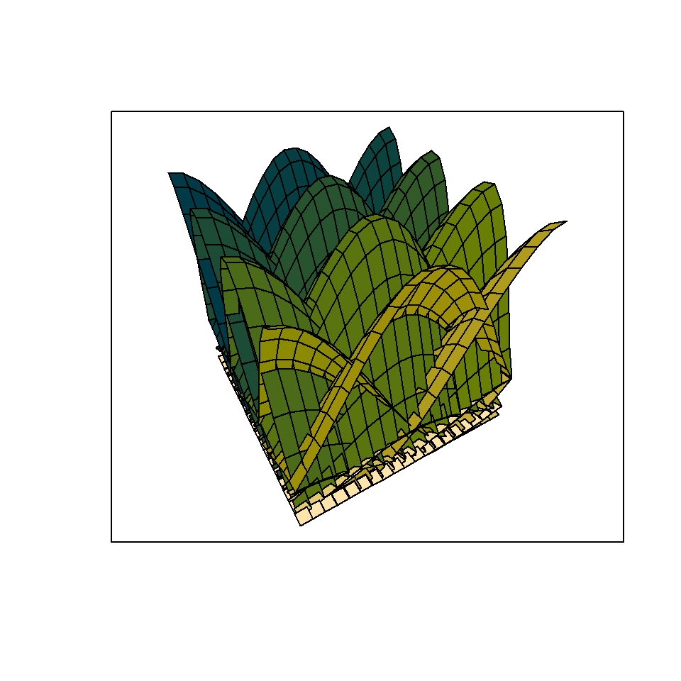

## The crossbasis

We can now rewrite our model

$$\begin{align}
\color{red}{\sum_{l} f(x_{t-l}, l)} &= \sum_{l}^L \sum_m^M \sum_k^K \theta_{mk} a_m(x_{t-l}) b_k(l) \\
& = \sum_m^M \sum_k^K \theta_{mk} \sum_{l}^L a_m(x_{t-l}) b_k(l)
\end{align}$$

which defines

- $M \times K$ bases $\sum_{l}^L a_m(x_{t-l}) b_k(l)$ cumulated over lags
- $M \times K$-dimensional parameter vector $\boldsymbol{\theta}$

## Matrix representation

The tensor product can be represented

$$\mathbf{a}^T(x) \boldsymbol{\Theta} \mathbf{b}(l) = \left(\mathbf{a}^T(x) \otimes \mathbf{b}^T(l)\right) \boldsymbol{\theta}$$

$\boldsymbol{\Theta}$ contains $\theta_{mk}$ at row $m$ and column $k$, and $\boldsymbol{\theta} = \text{vec}(\boldsymbol{\Theta})$

$\otimes$ is the Kronecker (outer) product

The model becomes

$$\sum_{l} f(x_{t-l}, l) = \sum_l \left(\mathbf{a}^T(x_{t-l}) \otimes \mathbf{b}^T(l)\right) \boldsymbol{\theta}$$

Therefore we can simply use $\color{red}{\mathbf{v}_t = \sum_l \left(\mathbf{a}^T(x_{t-l}) \otimes \mathbf{b}^T(l)\right)}$ as new variables

## Fitting a DLNM

We plug our new bases in the Poisson model

$$\mathbb{E}(y_t) = \exp \left(\alpha + \color{red}{\mathbf{v}_t \boldsymbol{\theta}} + \sum_{j=1}^p z_{tj} \gamma_j \right)$$

and the vector $\boldsymbol{\theta}$ can be used to reconstruct the surface

**This means DLNMs can be fitted through any linear model**

## Example results

Association between temperature and mortality

- Four quadratic B-splines on temperature dimension
- Four cubic B-splines on lag dimension

⇒ 16 bases in $\mathbf{v}_t$ and parameters $\boldsymbol{\theta}$

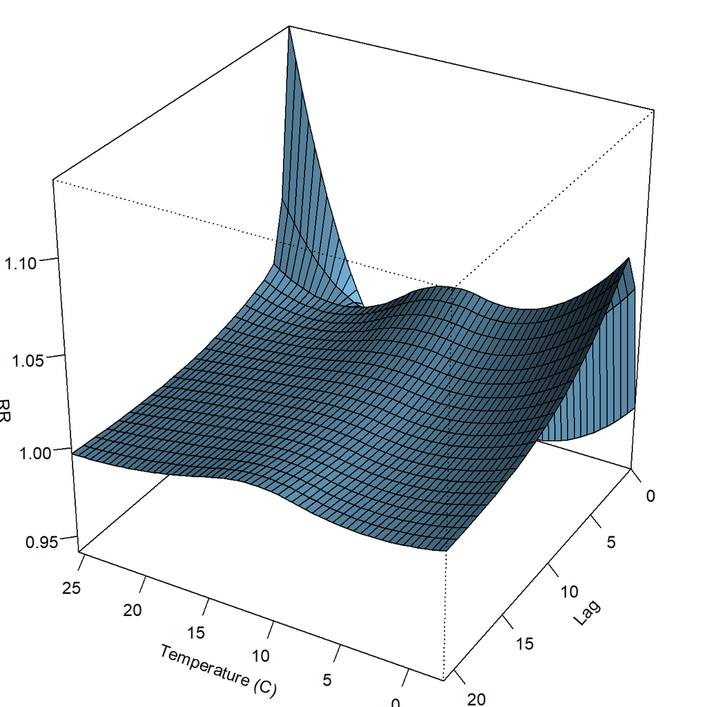

## Reducing DLNMs

We often want to reduce the surface to the **overall cumulative association**

$$f_{ov}(x) = \sum_l f(x,l) = \mathbf{a}^T(x)\boldsymbol{\theta}_{ov}$$

We can derive a **reduced** parameter vector $\boldsymbol{\theta}_{ov}$ that defined the cumulative association with the marginal basis $\mathbf{a}(x)$

$$\boldsymbol{\theta}_{ov} = \left(\sum_{l=0}^L \mathbf{b}^T(l) \right) \boldsymbol{\Theta}^T$$

## Inference

- DLNM plugs a crossbasis into a classical (generalised) linear model
- We can use classical theory to obtain the (co)variance matrix $V(\hat{\boldsymbol{\theta}})$
- Then derive $V(\hat{\boldsymbol{\theta}}_{ov})$
- Standard error for the curve at $x$:

$$\sqrt{\text{diag}\left(\mathbf{a}^T(x) V(\hat{\boldsymbol{\theta}}_{ov}) \mathbf{a}(x)\right)}$$

- Which can then be used for confidence intervals

## Overall cumulative of temperature

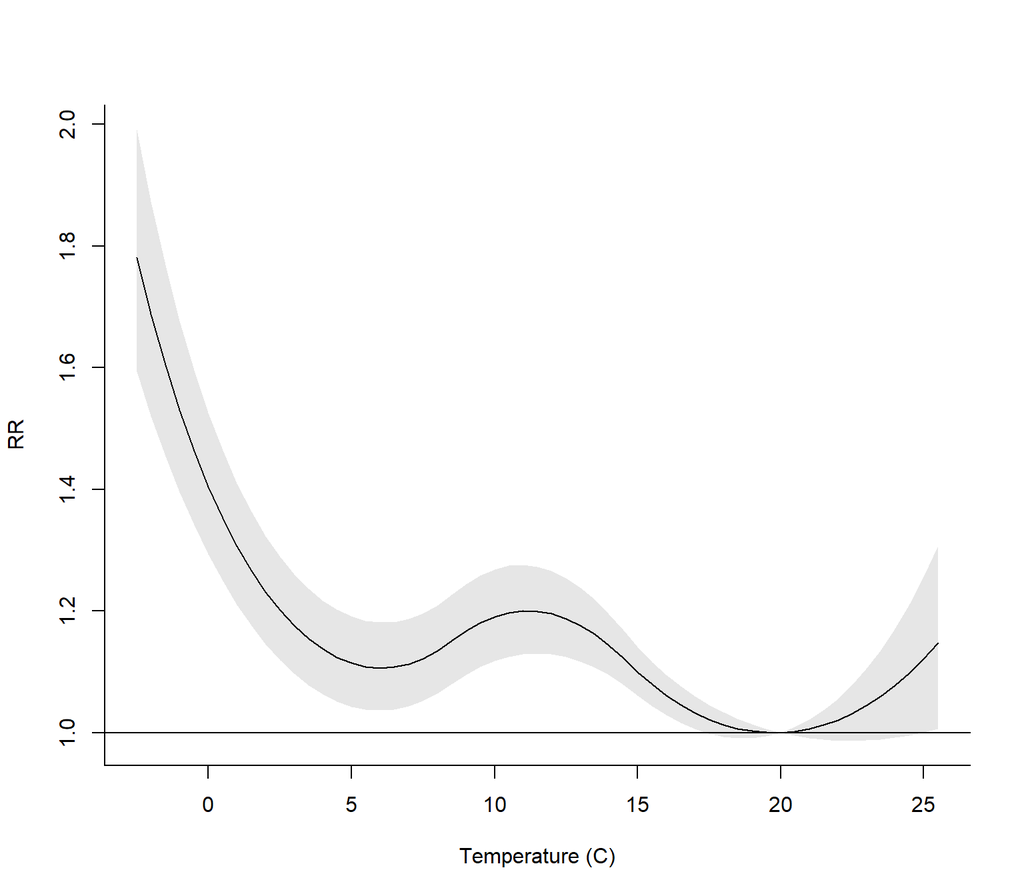

## Summary

To estimate the association between environmental exposures and health outcomes, we typically use **distributed lag nonlinear models** (DLNM)

Models associations that are

- Nonlinear
- Delayed

It works by building a **crossbasis**

## Software and code

Implemented for **R** in the package `dlnm`

The repo provides examples of how to use it

[figure not shown]

## Bibliographic notes

- DLMs were initially proposed by Almon (1965) for **econometrics**
- Introduced by Schwartz (2000) with polynomials to estimate the association between mortality and **air pollution**
- Zanobetti et al. (2000) used **splines in DLMs**
- Armstrong (2006) laid the ground work for **nonlinear** DLNMs with the aim of modelling temperature-related mortality
- Gasparrini et al. (2010) puts everything together developing the **algebra of DLNMs**
- Bhaskaran et al. (2013) provides an overview of the **time series design**

# Second-stage: meta-analysis

## Why multi-location studies

- We just saw the very complex DLNM

⇒ Needs a high number of cases for stable estimation

- Several locations allows higher power to estimate associations
- Vulnerability can vary between locations

## An example: the Italian dataset

- Temperature-related mortality
- 87 Italian cities
- 2011-2021

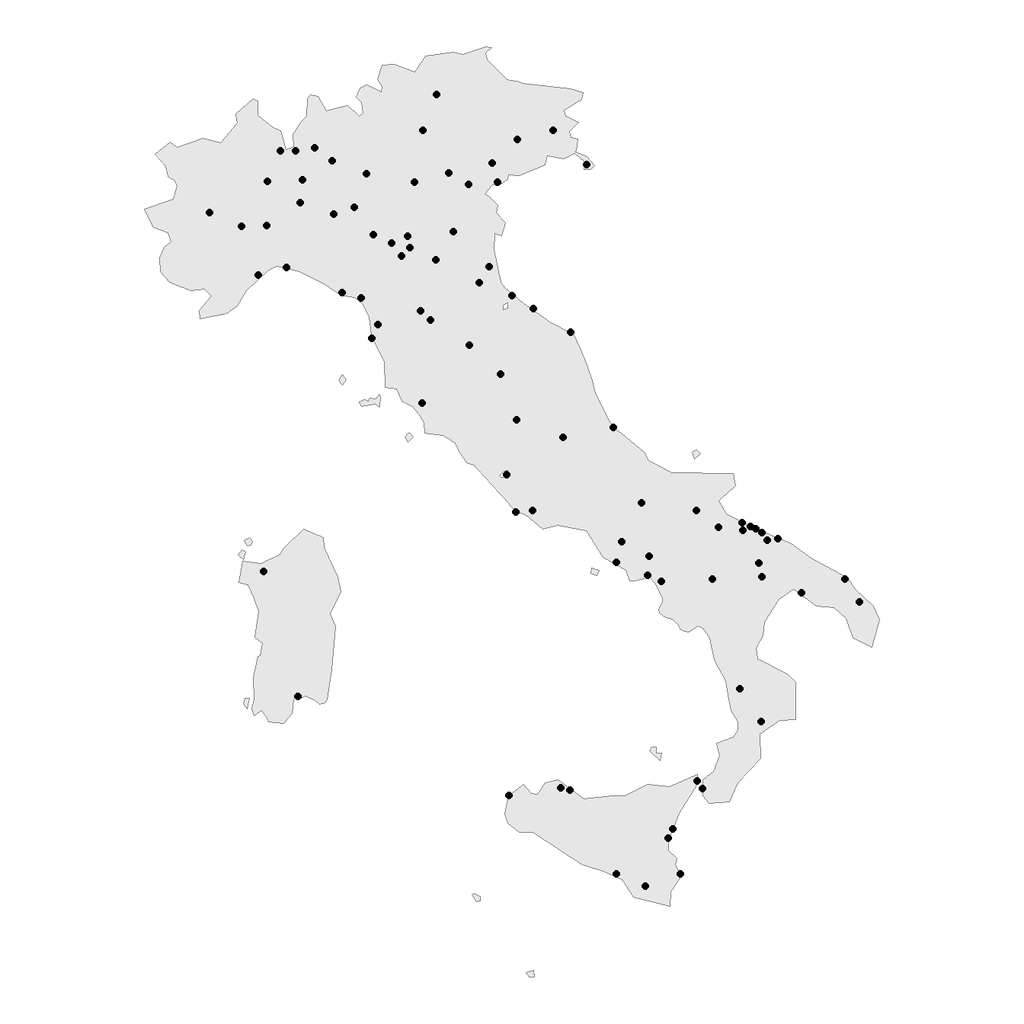

## First-stage

We fit a DLNM on each city independently

- 87 vectors of coefficients $\boldsymbol{\theta}_i = \hat{\boldsymbol{\theta}}_{ov}$
- 87 (co)-variance matrices $\mathbf{S}_i = V(\hat{\boldsymbol{\theta}}_{ov})$

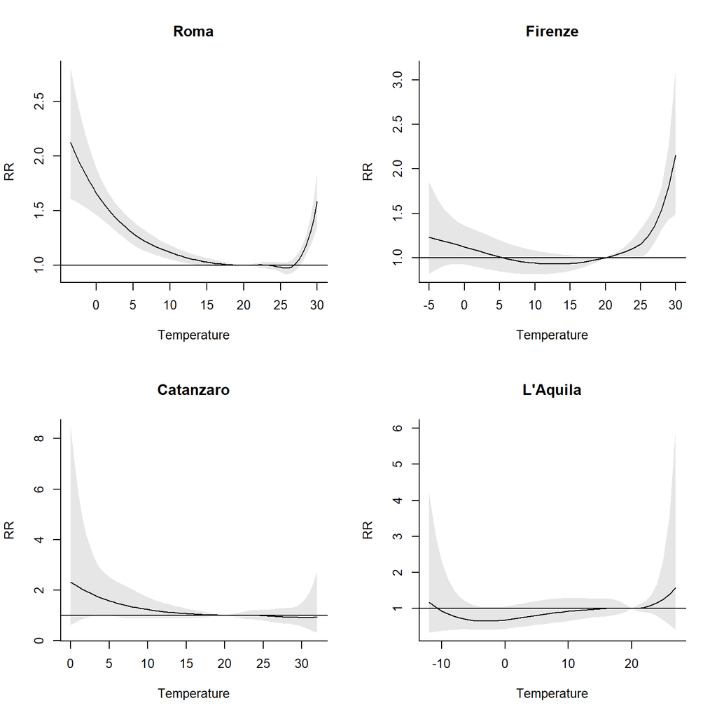

$\boldsymbol{\theta}_i$ and $\mathbf{S}_i$ are for lighter notation

## Pooling the curves: meta-analysis

Meta-analysis pools the parameter from several “studies” to improve power:

$$\boldsymbol{\theta}_i = \color{red}{\boldsymbol{\theta}} + \boldsymbol{\epsilon}_i$$

- $\color{red}{\boldsymbol{\theta}}$: The parameters that represents the association (DLNM)
- $i$ is the city index
- $\boldsymbol{\epsilon}_i \sim \mathcal{N}(\mathbf{0}, \mathbf{S}_i)$ is the error in city $i$
- $\mathbf{S}_i$ is the (co)-variance matrix estimated in first-stage

**Assumption**: The true association is the same in all cities

## Estimating the overall effect

The estimated $\color{red}{\boldsymbol{\theta}}$ is the weighted mean of the $\boldsymbol{\theta}_i$:

$$\hat{\boldsymbol{\theta}} = \left( \sum_i \mathbf{S}_i^{-1} \right)^{-1} \sum_i \mathbf{S}_i^{-1}\boldsymbol{\theta}_i$$

**Intuition**:

- The higher the variance $\mathbf{S}_i$, the lower the weight for city $i$
- Pulls $\hat{\boldsymbol{\theta}}$ towards the most accurate cities

## Meta-analysing Italian data

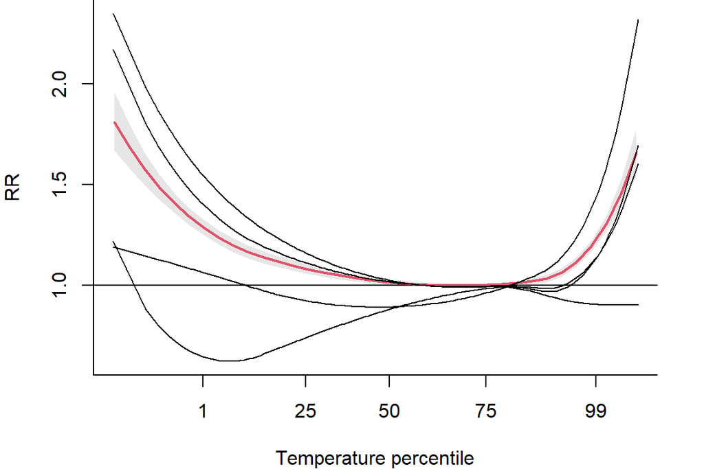

## Random effect meta-analysis

We can relax the assumption of common association

$$\boldsymbol{\theta}_i = \boldsymbol{\theta} + \boldsymbol{\xi}_i + \boldsymbol{\epsilon}_i$$

- $\boldsymbol{\xi}_i \sim \mathcal{N}(\mathbf{0}, \boldsymbol{\Psi})$: city-specific deviation from overall effect
- Now we have $\boldsymbol{\theta}_i \sim \mathcal{N}(\boldsymbol{\theta}, \mathbf{S}_i + \boldsymbol{\Psi})$

This model decomposes the between study variation into:

1. Error from first-stage statistical model ($\mathbf{S}_i$)
2. Heterogeneity of associations ($\boldsymbol{\Psi}$)

## Best linear unbiased predictions (BLUP)

We can predict associations from the model as

$$\hat{\boldsymbol{\theta}}_i = \color{red}{\hat{\boldsymbol{\theta}}} + \color{green}{\left(\mathbf{S}_i + \hat{\boldsymbol{\Psi}}\right)^{-1}\hat{\boldsymbol{\Psi}} \left(\boldsymbol{\theta}_i - \hat{\boldsymbol{\theta}}\right)}$$

- $\hat{\boldsymbol{\theta}}$ and $\hat{\boldsymbol{\Psi}}$ are *maximum-likelihood estimates*

The prediction sums two components:

1. The overall effect $\hat{\boldsymbol{\theta}}$
2. The part of the deviation that is due to the random effect $\hat{\boldsymbol{\Psi}}$

## BLUPs on Italian data

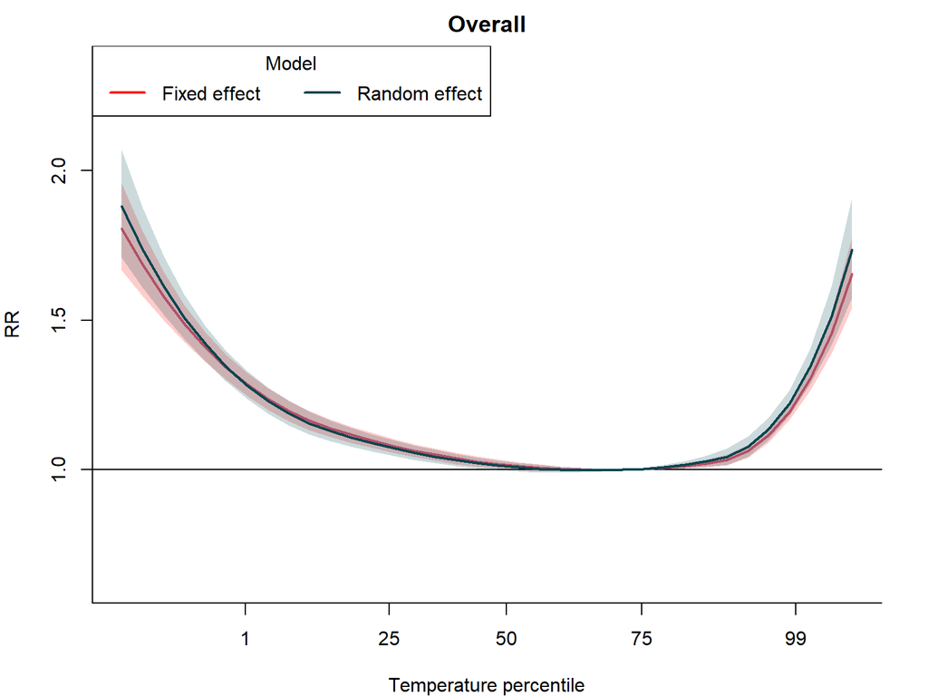

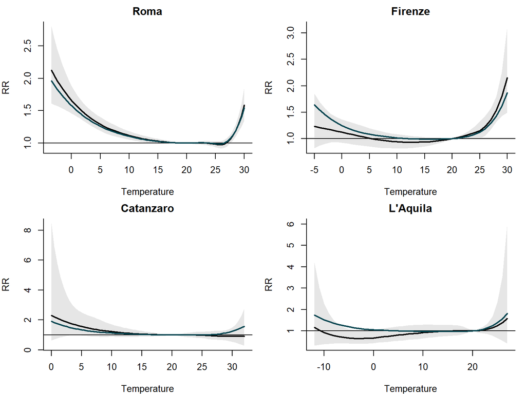

## Meta-regression

Random effect meta-analysis models heterogeneity, but doesn’t *associate it to city characteristics*

Meta-regression adds meta-predictors $\mathbf{X}_i$ **that can explain the heterogeneity**

$$\boldsymbol{\theta}_i = \mathbf{X}_i\boldsymbol{\beta} + \boldsymbol{\xi}_i + \boldsymbol{\epsilon}_i$$

- $\boldsymbol{\beta}$ is the effect of meta-predictors $\mathbf{X}_i$ on our association $\boldsymbol{\theta}_i$
- Now $\boldsymbol{\Psi}$ represents the heterogeneity that is explained neither by first-stage error or meta-predictors

## Interpreting meta-regression

We add *GDP per capita* as a meta-predictor

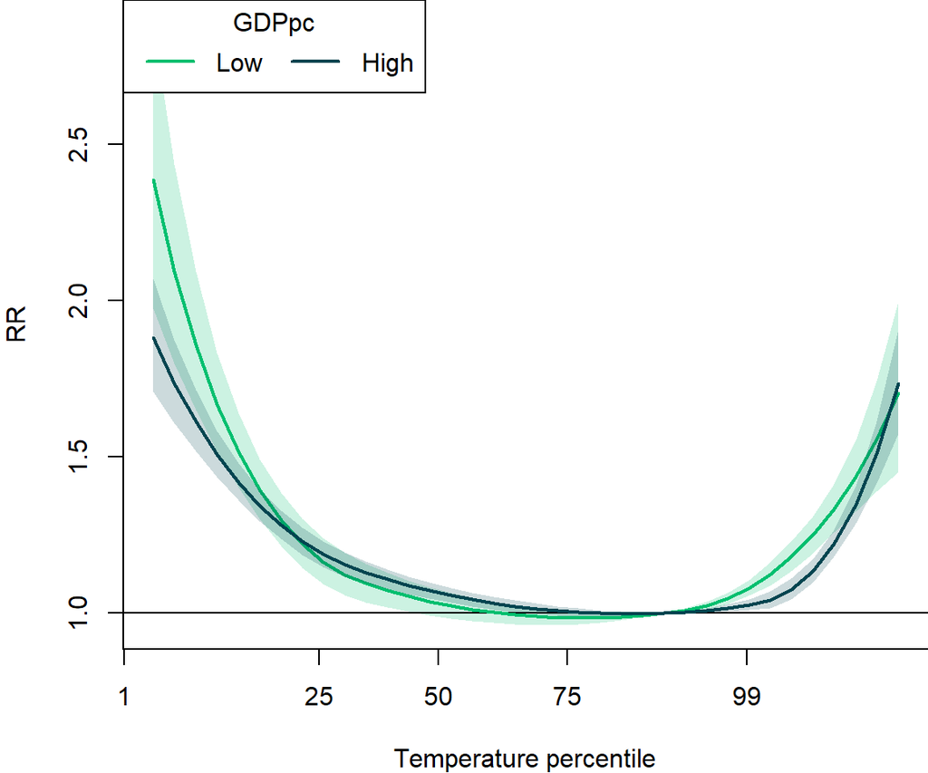

## The full mixed effects framework

All the models are generalised in the mixed-effects meta-regression framework

$$\boldsymbol{\theta}_i = \mathbf{X}_i\boldsymbol{\beta} + \mathbf{Z}_i\mathbf{b}_i + \boldsymbol{\epsilon}_i$$

- $\mathbf{Z}_i$ are random-effects meta-predictors whose effect $\mathbf{b}_i \sim \mathcal{N}(\mathbf{0}, \boldsymbol{\Psi})$ varies by city
- This notably allows multi-level random effects (city within country)

## Estimation

The model is estimated by Maximum-Likelihood

- This is a Gaussian likelihood

The log-likelihood is typically maximised either by:

- A full Expectation Maximisation algorithm
- Newton iterations

In both cases, iterates between updating $\hat{\boldsymbol{\beta}}$ and $\hat{\boldsymbol{\Psi}}$

## BLUPs again

The full model allows to compute BLUPs, obtaining improved estimates of the association in each city

$$\hat{\boldsymbol{\theta}}_i = \color{red}{\mathbf{X}_i\hat{\boldsymbol{\beta}}} + \color{green}{\left(\mathbf{S}_i + \mathbf{Z}_i\hat{\boldsymbol{\Psi}}\mathbf{Z}_i^T \right) ^{-1} \left(\mathbf{Z}_i\hat{\boldsymbol{\Psi}}\mathbf{Z}_i^T\right) \left(\boldsymbol{\theta}_i - \mathbf{X}_i\hat{\boldsymbol{\beta}}\right)}$$

Similar interpretation as before

- Fixed effect prediction
- Part of deviation due to random effect prediction

## Full BLUPs for Italian cities

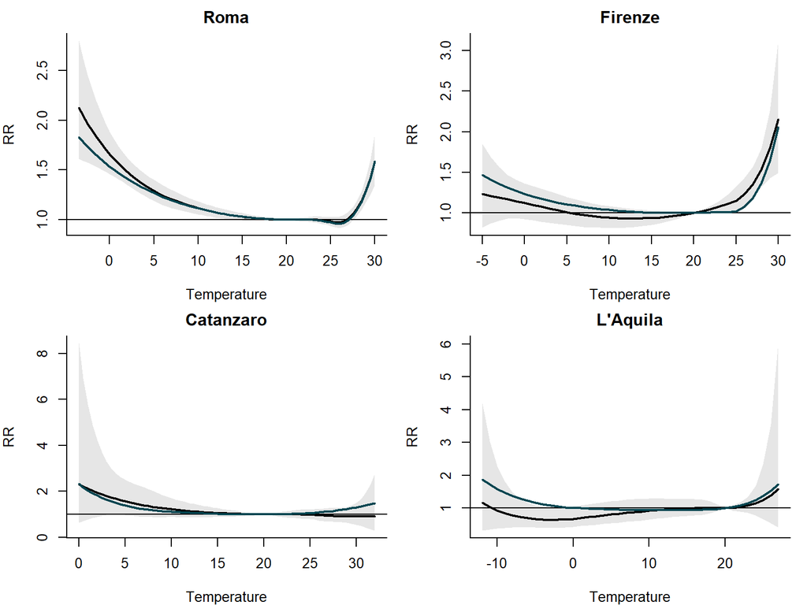

## The full framework

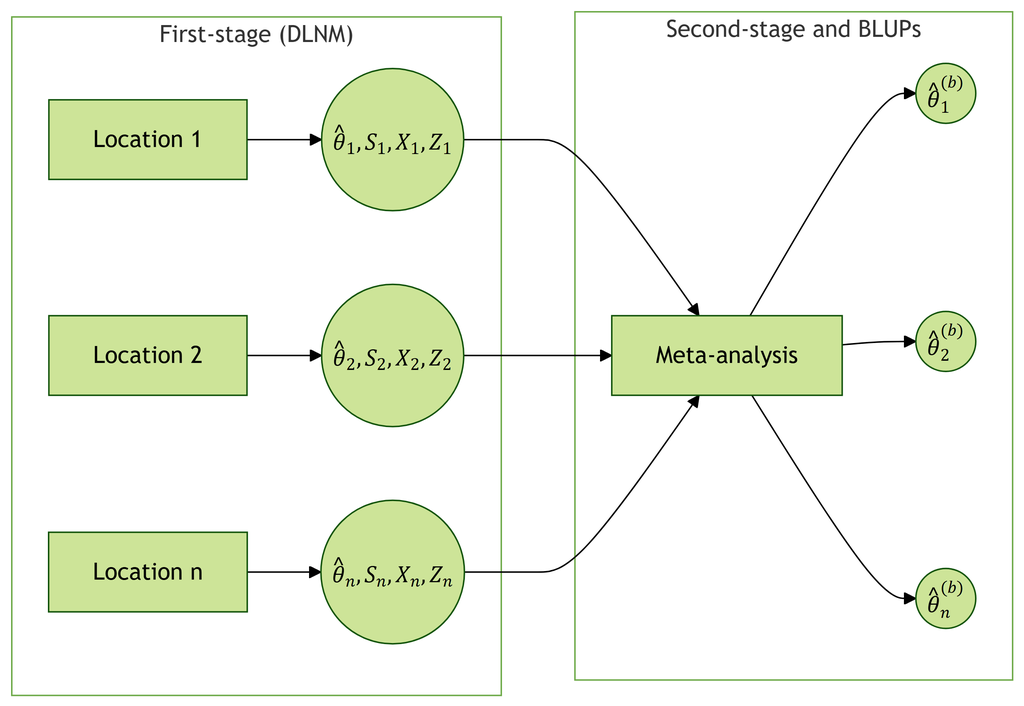

## Software and code

Meta-analysis implemented for **R** in the package `mixmeta`

Also see `meta`, `metafor` and `dmetar`

The repo provides examples of how to use it

[figure not shown]

## Bibliographic notes

- Dominici et al. (2000) used a **Bayesian hierarchical model** to pool log-linear associations of pollutants in 20 US cities.
- Gasparrini et al. (2012) proposed **multivariate meta-analysis** models to pool multi-parameter associations.
- Sera et al. (2019) developed the full **mixed-effects framework for meta-analysis and regression**.
- Sera and Gasparrini (2022) and - Masselot and Gasparrini (2025) provide **overviews and extensions for multi-location studies**.

# Some examples

## Temperature-related mortality across the world

$\boldsymbol{\theta}$: Five quadratic B-Spline parameters representing the overall cumulative association

Meta-analysis:

- Meta-predictors representing local characteristics
- City-level random effect ($\mathbf{Z} = \mathbf{I}_n$)

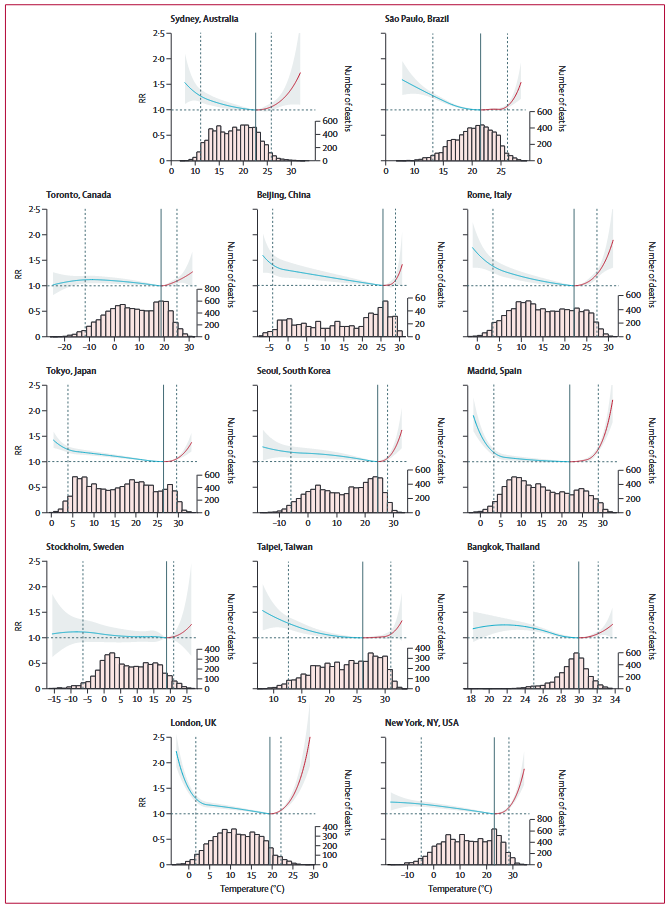

Gasparrini et al. (2015)

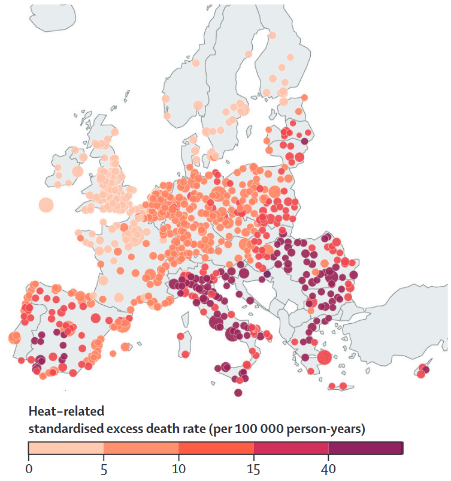

Masselot et al. (2023)

$\theta$: Single regression parameter for log-linear association

Meta-analysis:

- No meta-predictor
- **Multilevel** city within country random effect

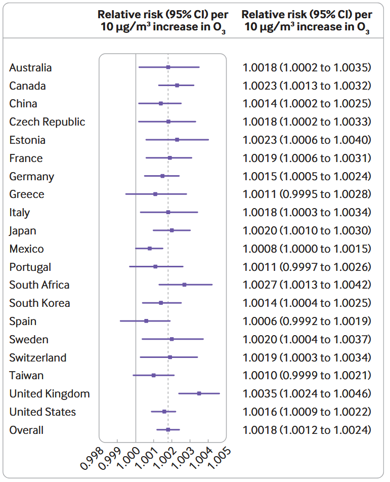

Vicedo-Cabrera et al. (2020)

## Air-conditioning and heat-related mortality

$\boldsymbol{\theta}$: Four quadratic B-Spline parameters representing the overall cumulative association

Meta-analysis:

- Meta-predictors: air-conditioning prevalence and other covariates
- City-level random effect

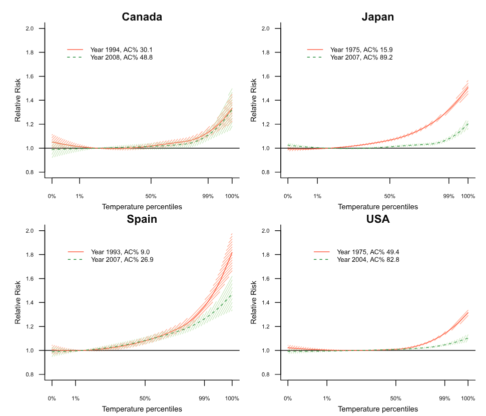

Sera et al. (2020)

# Conclusion

## Epidemiological framework

**Multi-location** framework for improved power and computational efficiency

1. Fit **location-specific model** to estimate the association of interest
2. **Pool** location-specific parameters into a meta-analysis model

This allows:

- Improved location-specific estimates
- Heterogeneity modelling

## Full material

- Slides (and Quarto document to generate them)
- Scripts for examples
- Data used in examples

[figure not shown]

## Bibliography

Almon, S., 1965. The Distributed Lag Between Capital Appropriations and Expenditures. Econometrica 33, 178–196. https://doi.org/10.2307/1911894

Anderson, B.G., Bell, M.L., 2009. Weather-Related Mortality: How Heat, Cold, and Heat Waves Affect Mortality in the United States. Epidemiology 20, 205. https://doi.org/10.1097/EDE.0b013e318190ee08

Armstrong, B., 2006. Models for the relationship between ambient temperature and daily mortality. Epidemiology 17, 624–631. https://doi.org/10.1097/01.ede.0000239732.50999.8f

Bhaskaran, K., Gasparrini, A., Hajat, S., Smeeth, L., Armstrong, B., 2013. Time series regression studies in environmental epidemiology. International Journal of Epidemiology 42, 1187–1195. https://doi.org/10.1093/ije/dyt092

Clark, S.N., Anenberg, S.C., Brauer, M., 2025. Global Burden of Disease from Environmental Factors. Annual Review of Public Health 46, 233–251. https://doi.org/10.1146/annurev-publhealth-071823-105338

Dockery, D.W., Pope, C.A., Xu, X., Spengler, J.D., Ware, J.H., Fay, M.E., Ferris, B.G., Speizer, F.E., 1993. An Association between Air Pollution and Mortality in Six U.S. Cities. New England Journal of Medicine 329, 1753–1759. https://doi.org/10.1056/NEJM199312093292401

Dominici, F., Samet, J.M., Zeger, S.L., 2000. Combining evidence on air pollution and daily mortality from the 20 largest US cities: A hierarchical modelling strategy. Journal of the Royal Statistical Society: Series A (Statistics in Society) 163, 263–302. https://doi.org/10.1111/1467-985X.00170

Gasparrini, A., Armstrong, B., Kenward, M.G., 2012. Multivariate meta-analysis for non-linear and other multi-parameter associations. Stat Med 31. https://doi.org/10.1002/sim.5471

Gasparrini, A., Armstrong, B., Kenward, M.G., 2010. Distributed lag non-linear models. Statistics in Medicine 29, 2224–2234. https://doi.org/10.1002/sim.3940

Gasparrini, A., Guo, Y., Hashizume, M., Lavigne, E., Zanobetti, A., Schwartz, J., Tobias, A., Tong, S., Rocklöv, J., Forsberg, B., Leone, M., De Sario, M., Bell, M.L., Guo, Y.-L.L., Wu, C., Kan, H., Yi, S.-M., de Sousa Zanotti Stagliorio Coelho, M., Saldiva, P.H.N., Honda, Y., Kim, H., Armstrong, B., 2015. Mortality risk attributable to high and low ambient temperature: A multicountry observational study. The Lancet 386, 369–375. https://doi.org/10.1016/S0140-6736(14)62114-0

Masselot, P., Gasparrini, A., 2025. Modelling extensions for multi-location studies in environmental epidemiology. Statistical Methods in Medical Research 34, 615–629. https://doi.org/10.1177/09622802241313284

Masselot, P., Mistry, M., Vanoli, J., Schneider, R., Iungman, T., Garcia-Leon, D., Ciscar, J.-C., Feyen, L., Orru, H., Urban, A., Breitner, S., Huber, V., Schneider, A., Samoli, E., Stafoggia, M., de’Donato, F., Rao, S., Armstrong, B., Nieuwenhuijsen, M., Vicedo-Cabrera, A.M., Gasparrini, A., MCC Collaborative Research Network, EXHAUSTION project, 2023. Excess mortality attributed to heat and cold: A health impact assessment study in 854 cities in Europe. The Lancet Planetary Health 7, e271–e281. https://doi.org/10.1016/S2542-5196(23)00023-2

Samet, J.M., Dominici, F., Curriero, F.C., Coursac, I., Zeger, S.L., 2000. Fine Particulate Air Pollution and Mortality in 20 U.S. Cities, 1987–1994. New England Journal of Medicine 343, 1742–1749. https://doi.org/10.1056/NEJM200012143432401

Schwartz, J., 2000. The distributed lag between air pollution and daily deaths. Epidemiology 11, 320–326.

Sera, F., Armstrong, B., Blangiardo, M., Gasparrini, A., 2019. An extended mixed-effects framework for meta-analysis. Statistics in Medicine 38, 5429–5444. https://doi.org/10.1002/sim.8362

Sera, F., Gasparrini, A., 2022. Extended two-stage designs for environmental research. Environmental Health 21, 41. https://doi.org/10.1186/s12940-022-00853-z

Sera, F., Hashizume, M., Honda, Y., Lavigne, E., Schwartz, J., Zanobetti, A., Tobias, A., Iñiguez, C., Vicedo-Cabrera, A.M., Blangiardo, M., Armstrong, B., Gasparrini, A., 2020. Air Conditioning and Heat-related Mortality: A Multi-country Longitudinal Study. Epidemiology 31, 779–787. https://doi.org/10.1097/EDE.0000000000001241

Vicedo-Cabrera, A.M., Sera, F., Liu, C., Armstrong, B., Milojevic, A., Guo, Y., Tong, S., Lavigne, E., Kyselý, J., Urban, A., Orru, H., Indermitte, E., Pascal, M., Huber, V., Schneider, A., Katsouyanni, K., Samoli, E., Stafoggia, M., Scortichini, M., Hashizume, M., Honda, Y., Ng, C.F.S., Hurtado-Diaz, M., Cruz, J., Silva, S., Madureira, J., Scovronick, N., Garland, R.M., Kim, H., Tobias, A., Íñiguez, C., Forsberg, B., Åström, C., Ragettli, M.S., Röösli, M., Guo, Y.-L.L., Chen, B.-Y., Zanobetti, A., Schwartz, J., Bell, M.L., Kan, H., Gasparrini, A., 2020. Short term association between ozone and mortality: Global two stage time series study in 406 locations in 20 countries. BMJ 368. https://doi.org/10.1136/bmj.m108

Zanobetti, A., Wand, M.P., Schwartz, J., Ryan, L.M., 2000. Generalized additive distributed lag models: Quantifying mortality displacement. Biostatistics 1, 279–292. https://doi.org/10.1093/biostatistics/1.3.279